# Análisis de Habilidades Blandas en Postgrados (Sección Brazil)

Julian Tejada y Juan C. Correa

2024-06-07

# Carga de datos

Primero, se carga el paquete “readtext” y se lee el directorio “Brazil” para extraer los textos de los documentos PDF. Luego, se elimina la extensión “.pdf” del identificador de cada documento.

```r
library(readtext)
textos <- readtext("Brazil")
textos$doc_id <- gsub(".pdf", "", textos$doc_id)
```

Luego, pasamos a relacionar cada programa de postgrado con su correspondiente nivel educativo para observar cuántos programas hay de cada nivel:

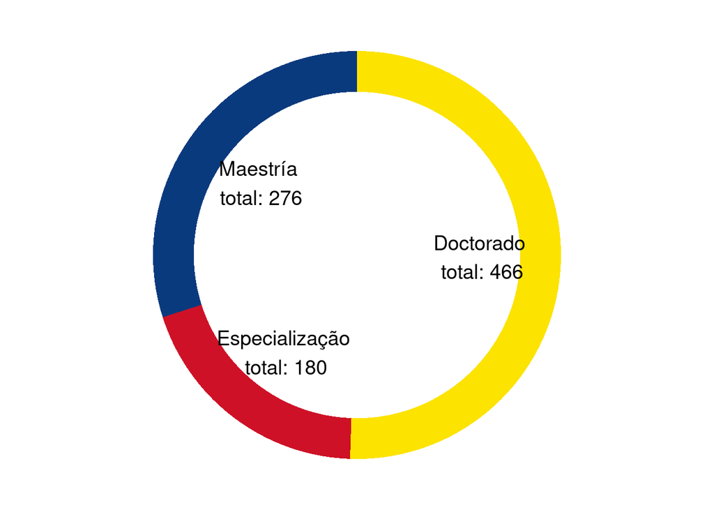

```r
library(dplyr)
textos <- mutate(textos,
                 Program = ifelse(
                   grepl("Doutorado", text), "Doctorado",
                        ifelse(grepl("Mestrado", text), "Maestría",
                               "Especialização")))
Programas <- data.frame(table(textos$Program))
colnames(Programas)[1] <- "Programa"
colnames(Programas)[2] <- "Total"

library(ggplot2)
Programas$fraction = Programas$Total / sum(Programas$Total)
Programas$ymax = cumsum(Programas$fraction)
Programas$ymin = c(0, head(Programas$ymax, n=-1))
Programas$ymax <- cumsum(Programas$fraction)
Programas$ymin <- c(0, head(Programas$ymax, n=-1))
Programas$labelPosition <- (Programas$ymax + Programas$ymin) / 2
Programas$label <- paste0(Programas$Programa, "\n total: ", Programas$Total)
ggplot(Programas, aes(ymax=ymax, ymin=ymin, xmax=4, xmin=3, fill=Programa)) +
  geom_rect() +
  geom_text(x=2, aes(y=labelPosition, label=label, color=Programa), size=5) +
  scale_fill_manual(values=c("Doctorado"="#FCE300", "Maestría"="#0A3A7E", "Especialização"="#CE1127")) +
  scale_color_manual(values=c("Doctorado"="black", "Maestría"="black", "Especialização"="black")) + # Custom text colors
  coord_polar(theta="y") +
  xlim(c(-1, 4)) +
  theme_void() +
  theme(legend.position = "none")
```

Ahora, pasamos a crear el corpus lingüístico. Para ello, cada documento se va a descomponer en número de palabras totales (tokens), número de palabras únicas (types) y número de oraciones (sentences). Esto nos permitirá observar la longitud de cada oferta de postgrado.

```r
library(quanteda)
Textos <- corpus(textos$text)
docvars(Textos, "Program") <- textos$Program
head(summary(Textos), 10)
```

```
##      Text Types Tokens Sentences        Program
## 1   text1   440    917        30      Doctorado
## 2   text2   373    771        29      Doctorado
## 3   text3   485   1175        45      Doctorado
## 4   text4   282    571        24      Doctorado
## 5   text5   231    624         6 Especialização
## 6   text6   231    624         6 Especialização
## 7   text7   412   1097        25       Maestría
## 8   text8   412   1097        25       Maestría
## 9   text9   139    348         5      Doctorado
## 10 text10   494   1553        35       Maestría
```

```r
Programs <- tokens(Textos,
                     remove_numbers = TRUE,
                     remove_punct = TRUE,
                     remove_url = TRUE,
                     remove_symbols = TRUE) %>%
  tokens_remove(stopwords("portuguese"))
```

Ahora, pasamos a hacer a buscar con el filtro contextual así:

```r
s1 <- data.frame(kwic(Programs, pattern = phrase("pensamento crítico")))
s2 <- data.frame(kwic(Programs, pattern = phrase("solução problemas")))
s3 <- data.frame(kwic(Programs, pattern = "comunicar"))
s4 <- data.frame(kwic(Programs, pattern = "criatividade"))
s5 <- data.frame(kwic(Programs, pattern = "tranqüilidade"))# paciencia
s6 <- data.frame(kwic(Programs, pattern = "criar"))
s7 <- data.frame(kwic(Programs, pattern = "liderar"))
s8 <- data.frame(kwic(Programs, pattern = "resolver"))
s9 <- data.frame(kwic(Programs, pattern = "comprometer"))
s10 <- data.frame(kwic(Programs, pattern = "comprometer-se"))
s11 <- data.frame(kwic(Programs, pattern = "gerenciar"))
s12 <- data.frame(kwic(Programs, pattern = "refletir"))
s13 <- data.frame(kwic(Programs, pattern = "verificar"))
s14 <- data.frame(kwic(Programs, pattern = "ético"))
s15 <- data.frame(kwic(Programs, pattern = "suportar")) # tolerar
s16 <- data.frame(kwic(Programs, pattern = "discutir"))
s17 <- data.frame(kwic(Programs, pattern = "conflitos"))
s18 <- data.frame(kwic(Programs, pattern = "negociação")) # negociar
s19 <- data.frame(kwic(Programs, pattern = "entender"))
s20 <- data.frame(kwic(Programs, pattern = "equipes"))
s21 <- data.frame(kwic(Programs, pattern = "planejar"))
s22 <- data.frame(kwic(Programs, pattern = "efetuar"))  # generar
s23 <- data.frame(kwic(Programs, pattern = "empatia"))
s24 <- data.frame(kwic(Programs, pattern = "compartilhar")) # compartir
s25 <- data.frame(kwic(Programs, pattern = "analisar"))
s26 <- data.frame(kwic(Programs, pattern = "reconhecer"))
s27 <- data.frame(kwic(Programs, pattern = "dirigir"))  # orientar
s28 <- data.frame(kwic(Programs, pattern = "respeito"))
s29 <- data.frame(kwic(Programs, pattern = "incentivar")) # motivar
s30 <- data.frame(kwic(Programs, pattern = "colaborar")) # cooperar
s31 <- data.frame(kwic(Programs, pattern = "fortalecer"))
s32 <- data.frame(kwic(Programs, pattern = "impulsionar")) # impulsar
s33 <- data.frame(kwic(Programs, pattern = "aproximar"))
s34 <- data.frame(kwic(Programs, pattern = "ajudar"))
s35 <- data.frame(kwic(Programs, pattern = "transformar")) # mudar
s36 <- data.frame(kwic(Programs, pattern = "gostar"))  # apreciar
s37 <- data.frame(kwic(Programs, pattern = "conduzir"))
s38 <- data.frame(kwic(Programs, pattern = "fomentar"))
s39 <- data.frame(kwic(Programs, pattern = "interagir"))
s40 <- data.frame(kwic(Programs, pattern = "identificar"))
s41 <- data.frame(kwic(Programs, pattern = "concorrer")) # competir
s42 <- data.frame(kwic(Programs, pattern = "demonstrar")) # manifestar
s43 <- data.frame(kwic(Programs, pattern = "responsável"))
s44 <- data.frame(kwic(Programs, pattern = "avaliar")) # evaluar
s45 <- data.frame(kwic(Programs, pattern = "inovar"))
s46 <- data.frame(kwic(Programs, pattern = "definir")) # decidir
s47 <- data.frame(kwic(Programs, pattern = phrase("tomada decisões")))
s48 <- data.frame(kwic(Programs, pattern = "flexibilidade"))
s49 <- data.frame(kwic(Programs, pattern = "aconselhar")) # persuadir
s50 <- data.frame(kwic(Programs, pattern = "incentivar")) # convencer

df_list <- mget(paste0("s", 1:50))
SS <- do.call(rbind, df_list)
SS$Skill <- rownames(SS)
SS$Skill <- gsub("\\..*", "", SS$Skill)
# rm(list=setdiff(ls(), "SS"))
variable.names(SS)
```

```
## [1] "docname" "from"    "to"      "pre"     "keyword" "post"    "pattern"
## [8] "Skill"
```

```r
head(SS, 5)
```

```
##      docname from  to                                                  pre
## s1.1  text79   39  40           bem temáticas inovadoras objetivo produzir
## s1.2 text182  111 112 ampla conceitual prática favorecendo desenvolvimento
## s1.3 text198  109 110             plena aliando conduta ética conhecimento
## s1.4 text213  370 371         Brasil carente programas acadêmicos voltados
## s1.5 text237   94  95      offline Promover atitudes empreendedora promove
##                 keyword
## s1.1 pensamento crítico
## s1.2 pensamento crítico
## s1.3 pensamento crítico
## s1.4 pensamento crítico
## s1.5 pensamento crítico
##                                                                     post
## s1.1                   relação problemas sociais culturais dimensionados
## s1.2 apropriação ferramentas instrumentos contribuam autodesenvolvimento
## s1.3                      partir visão interdisciplinar atuar iniciativa
## s1.4                       teórico cuja importância desenvolvimento país
## s1.5                    inovação organizacionais tocante gestão negócios
##                 pattern Skill
## s1.1 pensamento crítico    s1
## s1.2 pensamento crítico    s1
## s1.3 pensamento crítico    s1
## s1.4 pensamento crítico    s1
## s1.5 pensamento crítico    s1
```

```r
Skills <- data.frame(SkillCode = c(paste0("s", 1:50)),
                     Skill = c("pensamiento crítico",
                              "solucionar problemas",
                              "comunicar",
                              "creatividad",
                              "paciencia",
                              "crear",
                              "liderar",
                              "resolver",
                              "comprometer",
                              "comprometerse",
                              "gestionar",
                              "reflexionar",
                              "controlar",
                              "ético",
                              "tolerar",
                              "argumentar",
                              "conflictos",
                              "negociar",
                              "comprender",
                              "equipos",
                              "planificar",
                              "generar",
                              "empatía",
                              "compartir",
                              "analizar",
                              "reconocer",
                              "orientar",
                              "respetar",
                              "incentivar",
                              "cooperar",
                              "fortalecer",
                              "impulsar",
                              "aproximar",
                              "ayudar",
                              "transformar",
                              "gostar",
                              "dirigir",
                              "fomentar",
                              "interactuar",
                              "identificar",
                              "concorrer",
                              "demonstrar",
                              "responsable",
                              "evaluar",
                              "inovar",
                              "definir",
                              "tomada decisões",
                              "flexibilidad",
                              "aconselhar",
                              "incentivar"))
```

# Paso 2: (Modelado de Red de Habilidades)

Ahora, pasamos a modelar las relaciones entre las habilidades y los programas de postgrado. Para ello, vamos a usar los datos de la tabla SS resultante del último código del paso anterior para construir la redd a través de una lista de aristas.

```r
network <- SS[c(1,8)]
head(network, 3)
```

```
##      docname Skill
## s1.1  text79    s1
## s1.2 text182    s1
## s1.3 text198    s1
```

Ahora, pasamos a graficar la red bipartita entre habilidades y programas

```r
library(igraph)
bn2 <- graph.data.frame(network,directed=FALSE)
bipartite.mapping(bn2)
```

[output not shown]

[output cut: 49 more lines]

[output not shown]

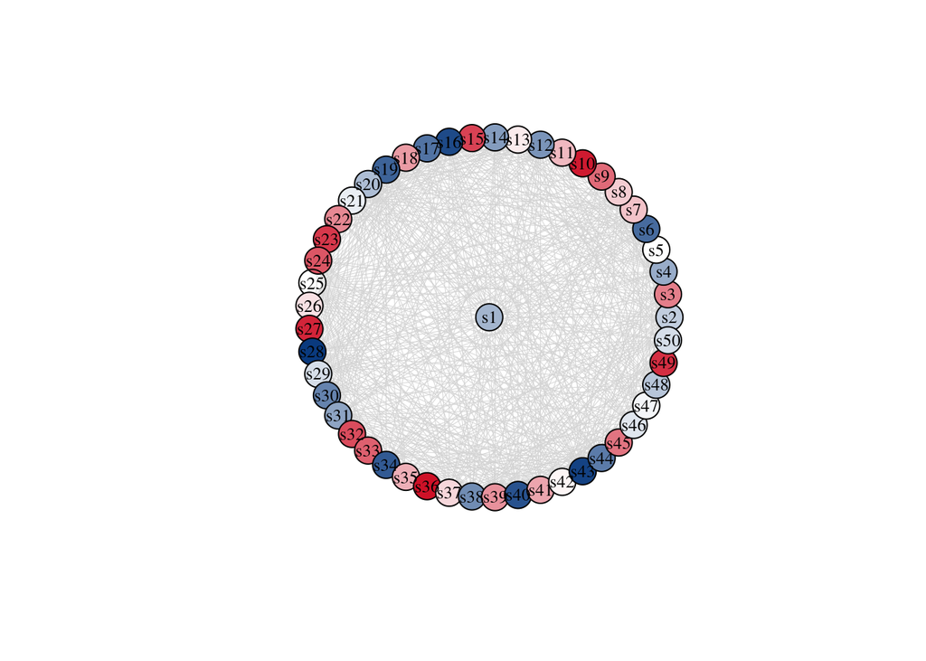

```r
V(bn2)$type <- bipartite_mapping(bn2)$type
V(bn2)$shape <- ifelse(V(bn2)$type, "circle", "square")
V(bn2)$label.cex <- ifelse(V(bn2)$type, 0.5, 1)
V(bn2)$size <- sqrt(igraph::degree(bn2))
E(bn2)$color <- "lightgrey"

bn2.pr <- bipartite.projection(bn2)
Terms <- bn2.pr$proj2

centrality_scores <- igraph::eigen_centrality(Terms)
centrality_scores <- centrality_scores$vector

color_palette <- colorRampPalette(c("#CE1127", "white", "#0A3A7E"))(length(unique(centrality_scores)))

# Assign colors to nodes based on their normalized centrality scores
node_colors <- color_palette[rank(centrality_scores)]

# Plot the network with node colors based on centrality
set.seed(915)


plot(Terms, vertex.label.color = "black", vertex.label.cex = 0.8, vertex.color = node_colors, vertex.size = 15, edge.width = 0.5, edge.color = "lightgray", layout = layout_as_star, main = "")
```

Seguimos con el cálculo de la importancia de cada habilidad y analicemos la correlación entre los cuatro indicadores de centralidad para ver si se comportan de una manera semejante a lo esperado por la evidencia empírica sobre indicadores de centralidad.

```r
BNA <- graph.data.frame(network, directed = FALSE)
Programs <- data.frame(Degree = igraph::degree(BNA),
                   Closeness = igraph::closeness(BNA),
                   Betweennes = igraph::betweenness(BNA),
                   Eigen = igraph::eigen_centrality(BNA))
Programs <- Programs[ -c(5:25) ]
rownames(Programs)
```

```
##   [1] "text79"  "text182" "text198" "text213" "text237" "text261" "text464"
##   [8] "text533" "text550" "text560" "text728" "text729" "text790" "text31"
##  [15] "text57"  "text73"  "text74"  "text94"  "text124" "text181" "text192"
##  [22] "text206" "text216" "text217" "text224" "text244" "text268" "text284"
##  [29] "text289" "text374" "text398" "text440" "text445" "text502" "text503"
##  [36] "text506" "text507" "text510" "text530" "text540" "text590" "text610"
##  [43] "text682" "text698" "text725" "text727" "text750" "text815" "text828"
##  [50] "text834" "text865" "text912" "text240" "text340" "text399" "text480"
##  [57] "text731" "text835" "text839" "text45"  "text50"  "text103" "text183"
##  [64] "text209" "text388" "text435" "text478" "text576" "text598" "text624"
##  [71] "text836" "text863" "text906" "text11"  "text12"  "text13"  "text39"
##  [78] "text53"  "text93"  "text99"  "text110" "text125" "text126" "text138"
##  [85] "text160" "text168" "text189" "text210" "text266" "text274" "text287"
##  [92] "text298" "text313" "text320" "text348" "text393" "text405" "text419"
##  [99] "text430" "text509" "text535" "text547" "text574" "text575" "text577"
```

[output cut: 56 more lines]

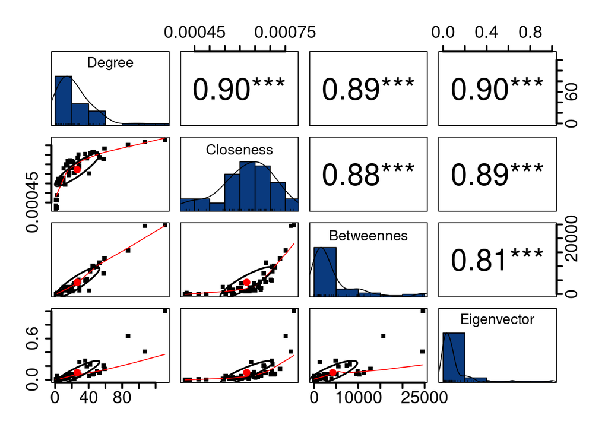

```r
Programs$SS <- rownames(Programs)
Programs <- Programs[order(Programs$SS), ]
Programs <- Programs[grepl("s", Programs$SS), ]
Programs <- Programs[1:4]
colnames(Programs)[4] <- "Eigenvector"

library(psych)

pairs.panels(Programs,
             method = "spearman",
             hist.col = "#0A3A7E",
             density = TRUE,
             ellipses = TRUE,
             pch = 15,
             cex = 1,
             cex.axis = 1.8,
             cex.labels = 1.5,
             lwd = 2,
             rug = TRUE,
             stars = TRUE)
```

Ahora, veamos el ranking de las diez habilidades más importantes

```r
IM <- as_incidence_matrix(BNA, names = TRUE, sparse = TRUE, types = bipartite_mapping(BNA)$type)
IM2 <- as.matrix(IM)

rownames(Programs)[order(Programs$Eigenvector, decreasing = TRUE)]
```

```
##  [1] "s25" "s28" "s43" "s16" "s34" "s40" "s17" "s19" "s6"  "s44" "s30" "s38"
## [13] "s12" "s31" "s14" "s48" "s4"  "s1"  "s20" "s2"  "s47" "s21" "s50" "s29"
## [25] "s26" "s46" "s5"  "s13" "s42" "s11" "s37" "s8"  "s35" "s7"  "s41" "s18"
## [37] "s22" "s45" "s3"  "s39" "s24" "s33" "s9"  "s15" "s23" "s32" "s49" "s10"
## [49] "s27" "s36"
```

```r
selected_columns <- head(rownames(Programs)[order(Programs$Eigenvector, decreasing = TRUE)], 10)
# Let's pick the most important soft skills
# as per their eigenvector centrality

current_column_names <- colnames(IM2)

# Subset the matrix by column names
IM3 <- IM2[, selected_columns, drop = FALSE]

current_column_names <- colnames(IM3)


# Create a vector to hold the mapped skill names
mapped_skill_names <- character(length(current_column_names))


for (i in seq_along(current_column_names)) {

  skill_index <- match(current_column_names[i], Skills$SkillCode)

  # If a match is found, map the skill code to its name
  if (!is.na(skill_index)) {
    mapped_skill_names[i] <- Skills$Skill[skill_index]
  } else {
    # Handle unmatched column names as needed
    # For example, assign a default value or leave blank
    mapped_skill_names[i] <- "Unmatched"
  }
}

# Replace the column names of IM3 with the mapped skill names
colnames(IM3) <- mapped_skill_names
colnames(IM3)
```

```
##  [1] "analizar"    "respetar"    "responsable" "argumentar"  "ayudar"
##  [6] "identificar" "conflictos"  "comprender"  "crear"       "evaluar"
```

# Paso 3 (Visualización de Red Bipartita)

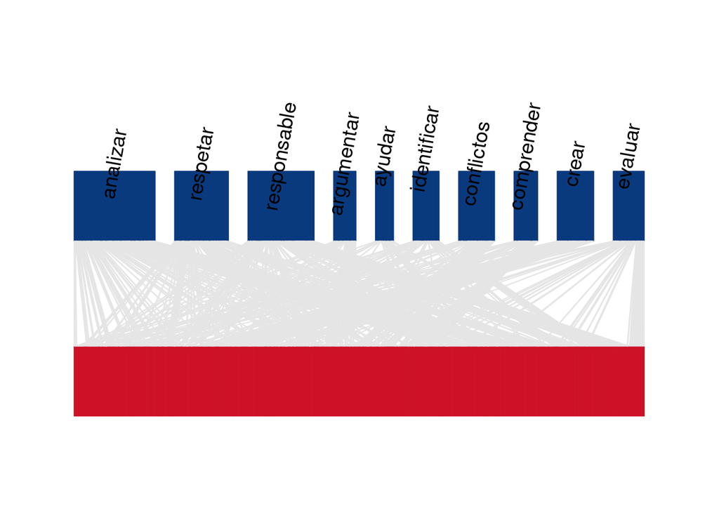

```r
library(bipartite)

plotweb(IM3, method = "normal",
        col.high = "#0A3A7E",
        bor.col.high = "#0A3A7E",
        col.low = "#CE1127",
        bor.col.low = "#CE1127",
        col.interaction = "grey90",
        bor.col.interaction = "grey90",
        low.lablength = 0,
        text.rot = 80,
        high.y = 1,
        ybig = 0.8,
        labsize = 2)
```